# Possible Improvements of Gyu-Kaku’s Operation and Effects on Revenue

Nan Nan, Chong Peng, Siyuan Song, Haoran Yang, Zehao Zhou

2023-12-07

# Abstract

During COVID-19, people need to follow the policy of staying at home. As people travel less, there are fewer customers to eat in physical restaurants, and the catering industry is somewhat affected (2022). After the pandemic, the catering industry still needs time to recover. In this case, the transformation of the business model is the catering industry’s future trend. Gyu-Kaku, one of the most popular barbecue restaurants in the United States, must pay attention to this change and make reforms accordingly.

In order to study how the restaurant can better adapt to the changing trend and find the appropriate way to have better revenue, we will study which method can help the restaurant achieve better revenue performance based on the dependent variables (payment and sales revenue per receipt) and independent variables (different ordering patterns and food delivery services).

The research focuses on order patterns and whether delivery services will have a change in revenue. This study used hypothesis and random selection analysis to collect receipts issued by Gyu-Kaku restaurants across the United States and confirm each period’s income according to the payment amount on the receipt sheet. Using simulation data to compare the new approach to the old one, the results show that ordering methods and delivery both would affect restaurant revenue.

# Statement of the Problem

During the 2019 coronavirus disease pandemic, the restaurant industry faced significant challenges. The main reasons for this situation were due to a sharp drop in patronage which was caused by policies of home segregation and heightened concerns about food safety during extraordinary times (Song et al., 2020). Under these circumstances, people will also have a higher expectation of the dining experience:

1. Over the years, the simplicity and lack of innovation in many restaurant menus have prompted customers to prefer exploring new culinary destinations. This phenomenon indicates a growing desire for diverse and unique dining experiences. Moreover, for restaurants, this is both a challenge and an opportunity.
2. The pandemic has also led to a shift in consumer behavior, with many people preferring to order takeout rather than eat out. This shift reflects ongoing concerns about health and safety in public places, as well as a growing reliance on takeaway platforms for restaurant-quality food. Collectively, these factors highlight the changing dynamics and operational challenges of customer preferences in the restaurant industry during and after the 2019 coronavirus disease pandemic.

# Literature Review

The catering industry, including the Japanese barbecue restaurant chain Gyu-Kaku, is navigating challenges such as rising dish prices due to inflation and the need to attract new customers in an increasingly competitive market (Idolgin, 2022). Gyu-Kaku, with over 70 branches in the United States (2023), is known for its spacious establishments and vibrant atmosphere, where customers enjoy grilling meat at their tables. Strategically located in high-traffic areas like city CBDs, the brand has established a strong presence in the industry (2023).

Gyu-Kaku traditionally offers two ordering modes: a la carte table menus and buffet, each having advantages and limitations post-pandemic (2023). The a la carte mode reduces contact and food cross-contamination, which is essential in the current health-conscious environment but may deter buffet enthusiasts. The buffet mode allows customers to choose within a time limit, but changing habits may affect revenue.

Furthermore, Gyu-Kaku is evaluating the impact of offering takeaway and delivery services (TDS) (2023). While TDS can open up new market segments and increase sales through partnerships with delivery platforms, there is a risk of diluting the brand’s image as a barbecue buffet destination. Balancing these factors is crucial for Gyu-Kaku’s continued success in the evolving catering industry.

# Research Questions

The U.S. Gyu-Kaku restaurant chain is focusing on two primary research questions to understand factors influencing its sales revenue:

1. How do sales revenues in the U.S. Gyu-Kaku restaurants vary based on the different ordering modes offered (À la carte or Buffet)?
2. Does the presence of Takeaway and Delivery Services (TDS) influence the sales revenue of Gyu-Kaku restaurants in the United States?

# Hypothesis

The first research question explores how different ordering modes (à la carte, buffet) impact sales revenue. This inquiry is framed within Hypothesis 1, contrasting the traditional view that these modes have no significant impact on sales (H0) against the possibility that they do (H1). The investigation considers the à la carte mode’s potential to provide personalized service and higher spending per table, and the buffet mode for its appeal to value-seeking customers.

The second research question investigates the impact of Takeaway and Delivery Services (TDS) on sales revenue, detailed in Hypothesis 2. This question assesses whether TDS, primarily through collaboration with major delivery platforms, has no effect (H0) or a significant effect (H1) on sales revenue. The role of TDS in enhancing brand visibility and attracting new customers is a crucial focus of this investigation.

These research questions are fundamental to Gyu-Kaku’s strategy for understanding and improving its financial performance in the competitive U.S. restaurant market.

# Importance of the Study and Social Impact

Research in the food service industry has provided valuable perspectives on enhancing sales revenue, mainly for establishments like Gyu-Kaku. One key area of focus is the food delivery services and ordering strategies to optimize operational efficiency and fiscal outcomes.

Insights from research suggest the importance of improving the dining experience through thoughtful modifications in the ambiance and ordering modes. Such enhancements can increase customer attraction and retention as they cater more directly to consumer preferences and expectations.

Furthermore, the study also emphasized that food delivery services have a significant sway in attracting customers to dine. Since the epidemic began to end, more and more people’s lifestyles have shifted from offline to online. In this case, restaurant delivery services are more in line with the contemporary requirements for dining. At the same time, this added service can also help restaurants attract more customers to increase revenue.

In terms of broader impacts, the research carries significant social and cultural implications. For instance, Gyu-Kaku improved the way of ordering and increased more methods to make customers’ lives easier. This enhancement in the dining experience improves the environment since customers would have more choices to have dinner, which could save more places and, to some extent, improve satisfaction.

From an economic perspective, implementing these research-based strategies could lead to better business performance for Gyu-Kaku, potentially resulting in increased job opportunities.Furthermore, a deeper understanding of customer inclinations and habits gleaned from this research can guide restaurants toward adopting more sustainable and environmentally friendly business practices, aligning with contemporary trends in consumer behavior and market dynamics.

# Research Plan

### Population

All the Gyu-kaku restaurants in the U.S.It includes various geographic locations and customer demographics.

### Sample Selection

In order to conduct our study, we are choosing 10 most representative restaurants from the population.

For geographical location, due to the fact that Gyu-kaku is a chain restaurant and the each franchise strictly follows the rule of location selecting. They are all located at CBD areas with large table turnover rate.

The selected restaurants should have a steady revenue trend in the past 2 years. And the selected 10 restaurants should have similar revenue data.

The selected timeframe will be the weekday only. Since restaurants revenue will vary a lot on weekends, in order to minimize the effect of cyclic trend, we will try to conduct our study only on weekdays. Also, these days should not include any holidays.(an average of 22 weekdays per month)

### Operational Procedures

Based on our sample selection methods, we will first filter out the restaurants with a revenue that’s significantly larger than the others. It can be done by conducting a test on the revenue data.

For those restaurants with a very similar revenue, we will then randomly select 10 restaurants from this pool. We will then repeat this process for our second experiment.

For our first experiment, we will start with the control group(Buffet Menu) and record the data we need for 1 month. Then we will switch to our treatment group(A la carte) for another month.

We will repeat the same step when we conduct the study for our second experiment.Our data recording part will keep on going for a total time of 4 months

With all the data, we will then create two dataset with day number and restaurant id, as well as their daily revenue under each group.

### Brief Schedule

This initial phase involves outlining the research design, preparing the necessary materials, and finalizing the logistics for the experiments. The preparation takes about two weeks.

The staff training time is about one week. The staff at the selected Gyu-Kaku restaurants will be trained on the specifics of the experiment. This includes understanding the different treatments (providing services for different ordering methods and tthe skills of operating with take-away services) and how to record and report data accurately.

Two months are needed to do the data collection for each experiment like described as operation procedures

After the data collection phase, the next two weeks will be dedicated to analyzing the data. The final phase involves compiling the findings into a comprehensive report.

### Data Collection

For the data collection phase of our study, we will primarily focus on gathering daily revenue data throughout the experimental period.

Since we need to assess the past revenue of the restaurants to make filter for sample selection, we will also need the past record of daily revenue.

For our dataset, it will include the day number and restaurant id as our first column, it is required to identified each recording of the datapoint.

### Data Security

Strict protocols are in place to ensure the utmost data security in our research. Access to the data stored in the database is exclusively granted to a select group of researchers. These individuals will undergo specialized training on data protection and preventing potential leaks.

Only after completing this training, evidenced by a certification, will they be authorized to view and edit the research data. Data collection will be strictly confined throughout the research process to information pertinent to the study. Furthermore, all collected data will be permanently deleted once the research concludes to uphold privacy standards and data integrity. This approach guarantees that data security is always maintained during our study.

### Variables

#### Dependent Variable

This study focuses on sales revenue as the primary dependent variable because it is a crucial measure of a restaurant’s performance. Sales revenue is straightforward to calculate and provides clear financial insights. This contrasts with other metrics, such as table turnover rates and variable costs, which can be challenging to track accurately or may fluctuate over short periods. Moreover, not meeting sales projections is often a more common concern than variations in these other factors.

#### Independent Variables

In this study, we investigate the impact of various operational aspects on restaurant performance, focusing on two key areas: ordering methods, and the availability of takeaway and delivery services. Both variables are considered having a potential impact on restaurant performance. Switching to different operational choices can significantly impact customer experience and business outcomes.

##### Order Methods

The restaurant’s ordering method is the first independent variable. We categorize this into two types: À la carte and Buffet. À la carte involves billing based on the cumulative price of dishes on each bill, while buffet billing is based on the number of customers. These two ordering options influence the dining experience, customer attraction, and consumer motivation, potentially affecting restaurant performance.

##### Take-out & Delivery Services(TDS)

The second aspect examines the impact of offering TDS. While TDS can offer convenience and increase a restaurant’s popularity, it may also affect food taste, increase operational costs, and lead to higher customer prices.

#### Other Variables

For further analysis, to conduct a more precise study and building a model with better performance, we might need to collect other variables rather than just daily revenue. These variables can also be strong indicators of the study. It can involve the componenets of the revenue, each receipt that’s created from the daily operation, the party size for each recipt, the table turnover rate, etc.

However, for our current study, they will not be put into use since the analysis of these variables may require substantial amount of resources.

### Statistical Analysis Plan

In our further analysis, we will employ several methods to examine the impact of different ordering mmethods and Takeaway & Delivery Services (TDS) availability on restaurant’s daily revenue.

*ANOVA Analysis:* We will use Analysis of Variance (ANOVA) to compare the mean sales revenue across different categories of ordering modes, and TDS availability. ANOVA is particularly suited for testing the impact of these categorical independent variables on a continuous dependent variable like sales revenue. This method will facilitate univariate analyses, allowing us to assess the effect of each variable independently.

*Multivariate Linear Regression:* To understand the combined effects of these factors, we will build a multivariate linear regression model. In this model, sales revenue will be the dependent variable, while the independent variables will include ordering modes, and TDS availability. This approach enables us to observe the relationship of each factor with sales revenue while controlling for the influence of the other variables, providing a more nuanced understanding of their collective impact.

*Model Evaluation using R-squared:* The model’s fit on the training data will be evaluated using the R-squared statistic. This measure will help us understand the proportion of variance in sales revenue that is explained by our model’s independent variables. A higher R-squared value would indicate the model’s more substantial explanatory power. Additionally, we will examine the residuals for normality to ensure the robustness of our model. Through these analytical methods, we aim to understand how different operational choices in restaurants influence their financial performance.

# Statistical Power & Sample Size

*Average Check Size:* For a mid-range dining establishment like Gyukaku, the average check per person could range from $25 to $50, depending on the location and menu items ordered. Let’s take an average of $37.50 per person.

*Number of Customers Per Day:* The number of customers a restaurant serves per day can vary greatly. For a moderately busy location, let’s assume it serves around 100 to 200 customers on a weekday. We’ll use the midpoint of 150 customers.

*Revenue Calculation (μ):* The daily revenue can be estimated by multiplying the average check size by the number of customers.

Daily Revenue = Average Check Size * Number of Customers

Daily Revenue = $37.50 * 150 = $5,625

*Effect Size (d):* A 10% increase in daily revenue. Assuming the average daily revenue is $5,625, a 10% increase would be $562.50.

*Standard Deviation (σ):* Since we don’t have actual data, let’s assume a standard deviation of $500. This is a bit arbitrary but is reasonable for revenue data.

*Desired Power (1 - β):* We’ll use the standard 80% power for calculation purposes since we are working with restaurant revenues and there’s no high consequences of having errors.

*Significance Level (α):* Set at 0.05, which is commonly used.

Using these parameters, we can calculate the sample size required for a study to detect a 10% increase in daily revenue with a standard deviation of $500, a power of 80%, and a significance level of 0.05.

```r
library(pwr)
# Parameters
power <- 0.80 # Desired power
alpha <- 0.05 # Significance level

# Calculate the effect size (Cohen's d)
d <- 562.5 / 500

# Calculate the required sample size
sample_size <- pwr.t.test(d = d, power = power, sig.level = alpha, type = "two.sample", alternative = "two.sided")$n

# Output the required sample size per group
cat("Required sample size per group:", sample_size, "\n")
```

```
## Required sample size per group: 13.43475
```

To detect a 10% increase in daily revenue with the parameters provided (standard deviation of $500, desired power of 80%, and significance level of 0.05), the estimated sample size required for each group in a two-sample t-test is approximately 13.4.

Since we can’t have a fraction of a sample, we would round this up to 14. This means we would need at least 14 observations in each group (e.g., 14 revenue data before and 14 revenue data after a change) to have a statistically robust test under these conditions.

### Sample Size

In order to control the study, we plan to use 10 restaurants that currently have similar revenues. They also have similar conditions(location, revenue, and other variables should be similar). In this setting, we would run the study for each scenario for 1 month. (22 days for each month since weekends may have a cyclic variation across the time. The sample size for each study will be controlled to:

22 days(average number of weekdays of a month) 10 selected restaurants(similar condition) = 220

For each study, there will be 220 observations. Each observation will show the revenue of a restaurant on a specific day on each treatment.

# Possible Recommendations

Based on the assumed findings of this study, we offer the following recommendations to Gyu-Kaku to improve their revenue performance:

*Optimize Ordering Methods:* Our study may find that different ordering methods significantly impact sales revenue. In this way, Gyu-Kaku should consider implementing a more streamlined and efficient ordering system to improve customer satisfaction and increase revenue.

*Enhanced TDS:* Our study also found that takeaway services positively impact revenue. Responding to changes in consumer spending patterns, Gyu-Kaku should consider expanding its takeaway services to attract more customers and increase revenue.

*Adopt Sustainable Practices:* Gyu-Kaku may consider adopting more sustainable and environmentally friendly business practices, such as reducing food waste, using eco-friendly packaging, and sourcing ingredients locally. These practices align with contemporary trends in consumer behavior and market dynamics and can enhance the restaurant’s reputation and attract more customers.

*Conduct Further Research:* While this study provides valuable insights, further research must confirm and expand upon these findings.Gyu-Kaku should consider conducting a more extensive, long-term study across various locations to yield more reliable conclusions and inform future operational decisions.

By implementing these recommendations, gyu-Kaku can optimize its operations, enhance the dining experience, and increase revenue.

# Limitations and Uncertainties

While this study provides valuable insights into the impact of different operational factors on Gyu-Kaku’s revenue performance, it is essential to acknowledge the limitations of the research.

One significant limitation is the reliance on sales revenue as the primary performance indicator. While sales revenue is a crucial measure of a restaurant’s performance, it needs to comprehensively evaluate other critical factors such as variable costs, table turnover rates, customer satisfaction, and food quality. Future research could consider incorporating these additional metrics to provide a more robust understanding of performance over time.

Another area for improvement is the use of convenience sampling and the challenges in uniformly controlling operations. While regression analysis can mitigate potential confounding factors, inherent uncertainties will remain. A more extensive, long-term study across various locations would yield more reliable conclusions.

Additionally, the short duration of the treatment study, which lasted only one month, provides a limited view of the long-term effects of the interventions. Such a short time frame restricts the ability to observe enduring impacts. Future research could consider extending the treatment study’s duration to capture the interventions’ long-term effects.

Acknowledging these limitations is crucial for appropriately interpreting and applying the study’s results. While the findings provide valuable insights into Gyu-Kaku’s operations and revenue performance, further research is necessary to confirm and expand upon these findings.

# Simulated Studies

*Research Question 1:* How do sales revenues in the U.S. Gyu-Kaku restaurants vary based on the different ordering modes offered (À la carte, Buffet)?

*Scenario 1 (No effect):*

For this analysis, we established a dataset hypothesizing the absence of impact on daily sales revenues due to the mode of ordering. The dataset was constructed to reflect no significant variation between revenues from À la carte and Buffet modes, with identical Mean for both categories.

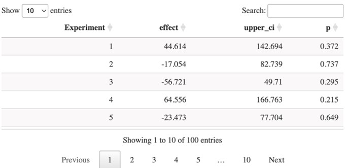

*Scenario 2 (Has an Effect):*

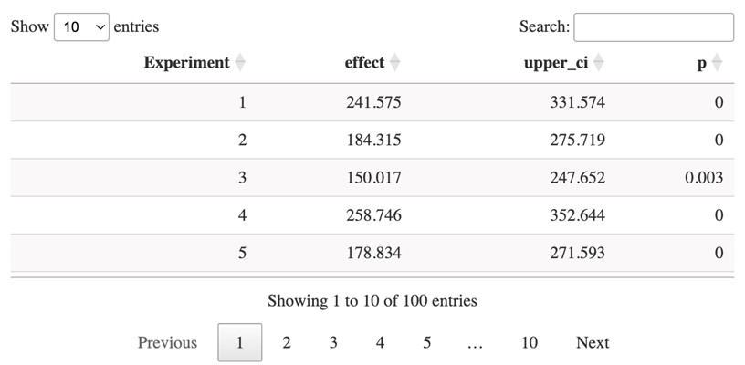

*Research Question 2:* Does take-out service increase the sales revenue of Gyu-Kaku restaurants in the United States?

*Scenario 1 (No Effect):*

In this scenario, we created a dataframe that assumes there’s no influence on the daily revenue when we implement the take-out service. Thus, the parameters we used for our control and treatment group are the same.

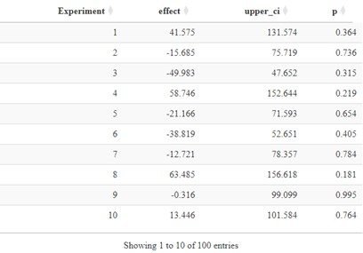

*Scenario 2 (has an effect):*

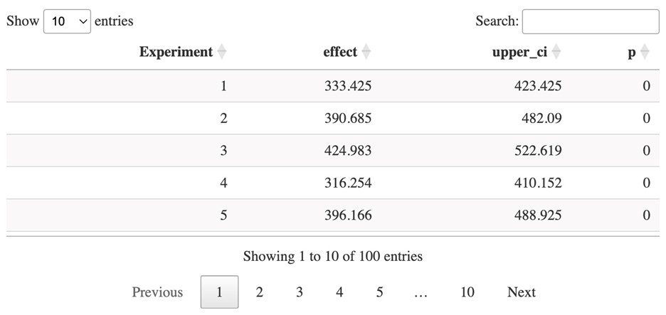

# Conclusion

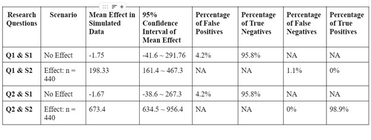

In conclusion, the simulation study on Gyu-Kaku’s operations has provided valuable insights into the impact of different ordering methods and takeaway services on sales revenue.

The findings indicate a significant mean effect of ordering methods on revenue, highlighting the importance of considering the diverse impact of various ordering modes on Gyu-Kaku’s financial performance. Additionally, the positive and significant average effect of takeaway services in expected scenarios underscores the need to recognize the potential influence of takeaway offerings on revenue generation.

It is essential to acknowledge the limitations of this study, including its observational nature and the need for a longer-term, randomized, controlled trial across multiple locations to enhance the validity and causal inference of the findings. Furthermore, while focusing on sales revenue, Gyu-Kaku needs to consider other factors, such as variable costs, customer satisfaction, and food quality, to evaluate restaurant performance comprehensively.

These insights provide a foundation for Gyu-Kaku to make informed decisions regarding its operational strategies, particularly in the post-COVID-19 landscape. By considering the impact of different ordering methods and takeaway services on revenue, Gyu-Kaku can refine its approach to meet evolving customer preferences and enhance its financial performance in the competitive restaurant market.

Last but not least, although simulated data is not the actual dataset, it can be instrumental in complex systems like restaurants, where multiple factors can influence revenue generation. Furthermore, simulated data can help to predict outcomes under various operational changes, providing insights into the potential impact of different strategies on revenue. This approach can help Gyu-Kaku to make informed decisions about its operational strategies and identify areas for improvement.

# Reference

Greenwald, M. (2020, December 17). 10 inspiring restaurant and food service business model pivots to survive and thrive since Covid. Forbes. https://www.forbes.com/sites/michellegreenwald/2020/12/17/11-inspiring-restaurant--food-service-business-model-pivots-post-covid/?sh=37272f58425c

Idolgin. (2022, December 16). The 4 biggest challenges restaurant owners will face in 2023: Grubhub. Grubhub for Restaurants. https://get.grubhub.com/blog/biggest-challenges-restaurants-face/

Madeira, A., Palrão, T., & Mendes, A. S. (2020, December 23). The impact of pandemic crisis on the restaurant business. MDPI. https://www.mdpi.com/2071-1050/13/1/40

Pamela, R. (2023, September 5). How to do restaurant delivery properly and increase sales & profits. WISK Restaurant Software. https://www.wisk.ai/blog/how-to-expand-your-restaurant-with-food-delivery#:~:text=Implementing%20restaurant%20delivery%20services%20has,(with%20something%20for%20everyone).

Report: Pandemic leads to long-term industry changes. NRA. (2022). https://restaurant.org/education-and-resources/resource-library/new-2022-state-of-the-restaurant-industry-report-projects-trends/

Song, H. J., Yeon, J., & Lee, S. (2020, October 1). Impact of the COVID-19 pandemic: Evidence from the U.S. restaurant industry. International Journal of Hospitality Management. https://www.sciencedirect.com/science/article/pii/S0278431920302541

Team, Lineup. ai. (2022, September 7). The 7 factors affecting restaurant sales. https://lineup.ai/blog/7-major-factors-affecting-restaurant-sales/

The top 3 factors that affect restaurant revenue. Taker. (2021, October 20). https://taker.io/blog/the-top-3-factors-that-affect-restaurant-revenue

Who we - gyu-kaku.com. GYU-KAKU Japanese BBQ restaurant. (2023). https://www.gyu-kaku.com/wp-content/uploads/2023/08/brochure_franchise2308_web.pdf